# series temporais

Análise de Séries Temporais é uma técnica poderosa para entender o passado e fazer predições.

Aqui analisaremos a tendência das taxas de detecção de casos novos de hanseníase no Brasil, entre os anos de 2001 a 2019 e faremos sua predição.

A taxa de detecção geral de casos novos de hanseníase por 100 mil habitantes, entre 2001 a 2019, apresenta uma mediana de 18,22, sendo que 25% dos valores observados estão abaixo 14,70 e 75% estão abaixo de 24,99.

```
##    Min. 1st Qu.  Median    Mean 3rd Qu.    Max.
##   12.23   14.70   18.22   19.69   24.99   29.37
```

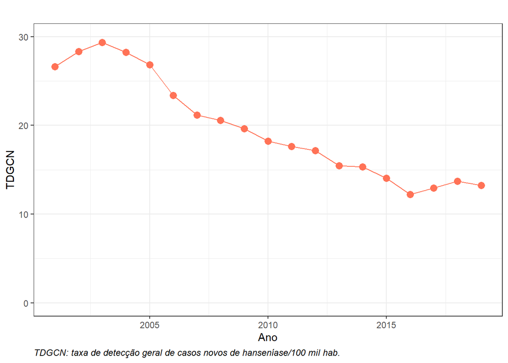

O teste de Mann-Kendall confirma formalmente, a um *p-valor* <0,05, a presença de tendência negativa na série temporal observada.

```
## # A tibble: 1 x 5
##   statistic     p.value kendall_score denominator var_kendall_score
##       <dbl>       <dbl>         <dbl>       <dbl>             <dbl>
## 1    -0.883 0.000000154          -151        171.               817
```

Podemos distinguir a tendência utilizando a regressão polinomial local.

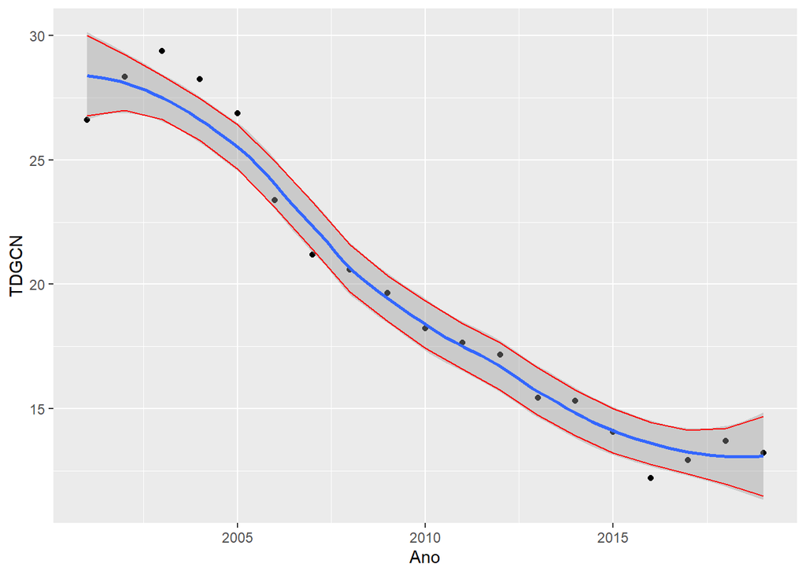

Para a seleção de um modelo de predição a série foi dividida entre série de treino e de teste.

Verificou-se que mesmo não havendo evidências de estacionariedade, optou-se por fazer apenas diferenciação de primeira ordem, já que não foi possível obter melhores resultados além do encontrado.

```
##
##  Augmented Dickey-Fuller Test
##
## data:  d1
## Dickey-Fuller = -2.7088, Lag order = 2, p-value = 0.3023
## alternative hypothesis: stationary
```

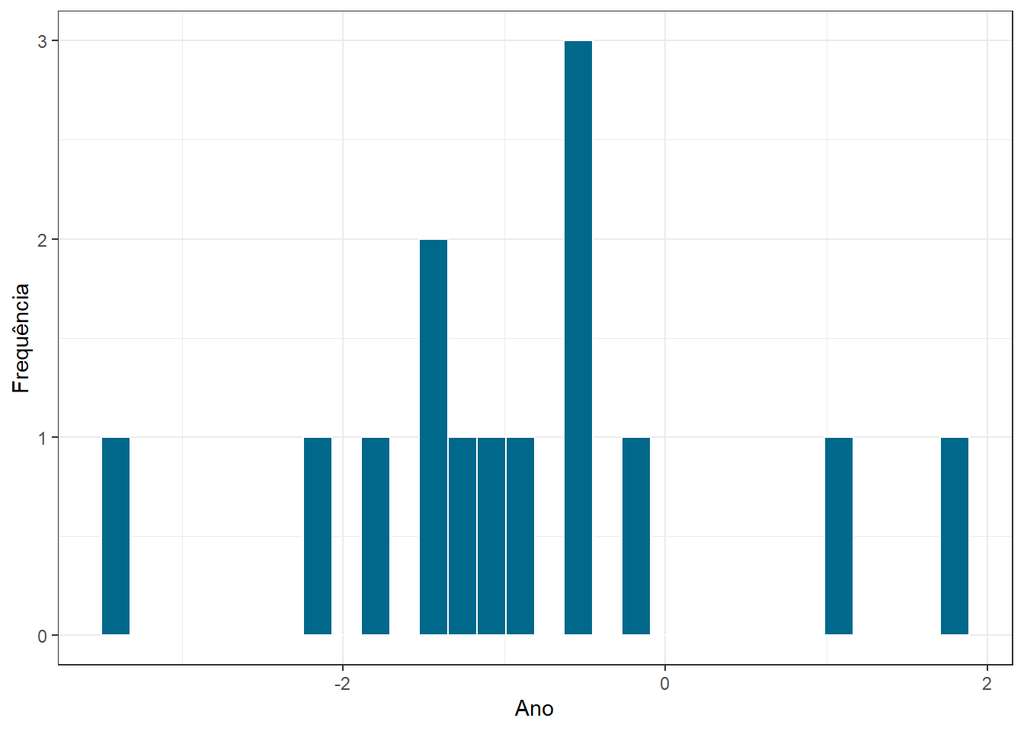

# Modelo ARIMA

Foi escolhido o modelo ARIMA para realizar a predição das taxas.

Baseado nos resultados da função de autocorrelação (FAC) e da função de autocorrelação parcial (FACP), é possível estimar um modelo ARIMA (0,1,0).

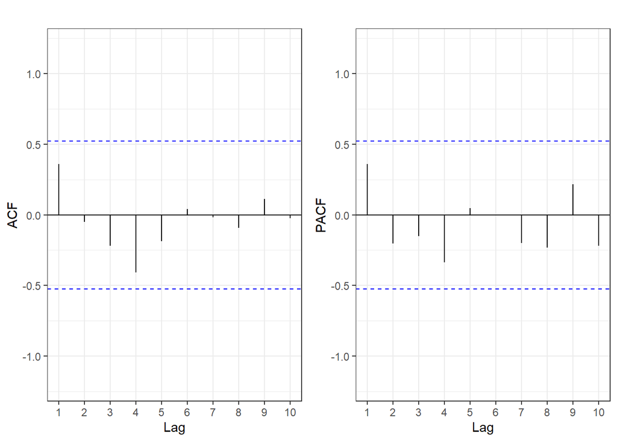

```
## [1] "FAC e FACP"
```

A Inclusão do drift se dá pelo fato de a série temporal estudada se tratar de um passeio aleatório. Portanto, essa forma retorna um menor valor AIC.

```r
mod_arima <- Arima(treino, order = c(0,1,0), include.drift = T)
print(mod_arima)
```

```
## Series: treino
## ARIMA(0,1,0) with drift
##
## Coefficients:
##         drift
##       -0.8957
## s.e.   0.3299
##
## sigma^2 estimated as 1.64:  log likelihood=-22.81
## AIC=49.62   AICc=50.71   BIC=50.9
```

```
##      Point Forecast     Lo 80    Hi 80     Lo 95    Hi 95
## 2016       13.17429 11.532856 14.81571 10.663936 15.68464
## 2017       12.27857  9.957240 14.59990  8.728401 15.82874
## 2018       11.38286  8.539818 14.22590  7.034805 15.73091
## 2019       10.48714  7.204284 13.77000  5.466444 15.50784
```

Ao observar os resíduos do modelo, tem-se que não estão autocorrelacionados.

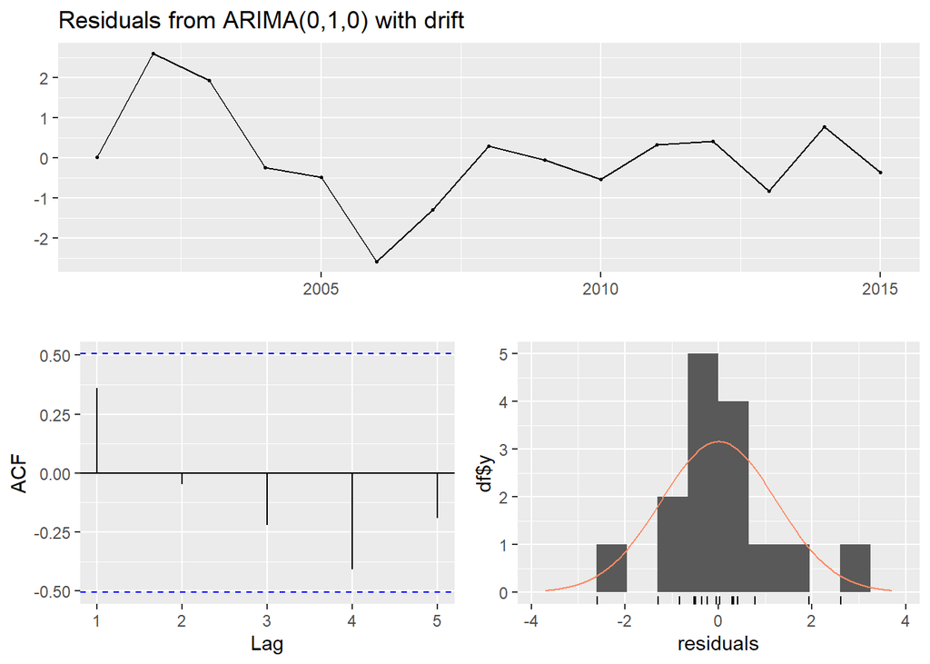

```
##
##  Ljung-Box test
##
## data:  Residuals from ARIMA(0,1,0) with drift
## Q* = 7.3432, df = 3, p-value = 0.06173
##
## Model df: 1.   Total lags used: 4
```

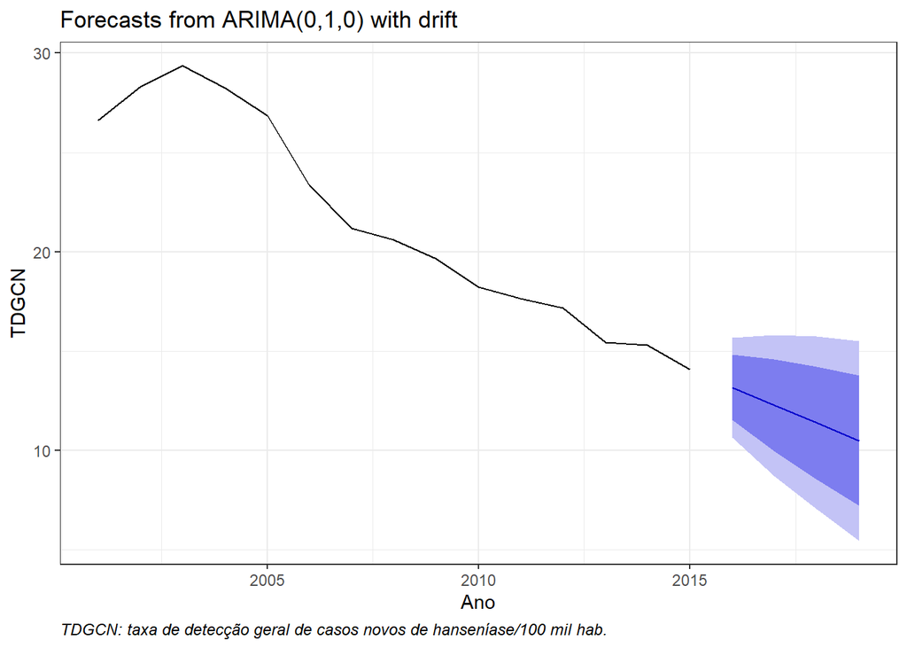

# Modelo de Suavização Exponencial (ETS)

Para contrastar com o modelo ARIMA aplicado podemos utilizar o modelo ETS.

```
## ETS(M,N,N)
##
## Call:
##  ets(y = treino)
##
##   Smoothing parameters:
##     alpha = 0.9999
##
##   Initial states:
##     l = 26.5009
##
##   sigma:  0.0689
##
##      AIC     AICc      BIC
## 56.63705 58.81887 58.76120
```

```r
prev_ets <- forecast(mod_ets, h = 4)
print(prev_ets)
```

```
##      Point Forecast    Lo 80    Hi 80    Lo 95    Hi 95
## 2016       14.07013 12.82740 15.31285 12.16954 15.97071
## 2017       14.07013 12.31065 15.82960 11.37924 16.76101
## 2018       14.07013 11.91269 16.22756 10.77062 17.36963
## 2019       14.07013 11.57600 16.56425 10.25569 17.88456
```

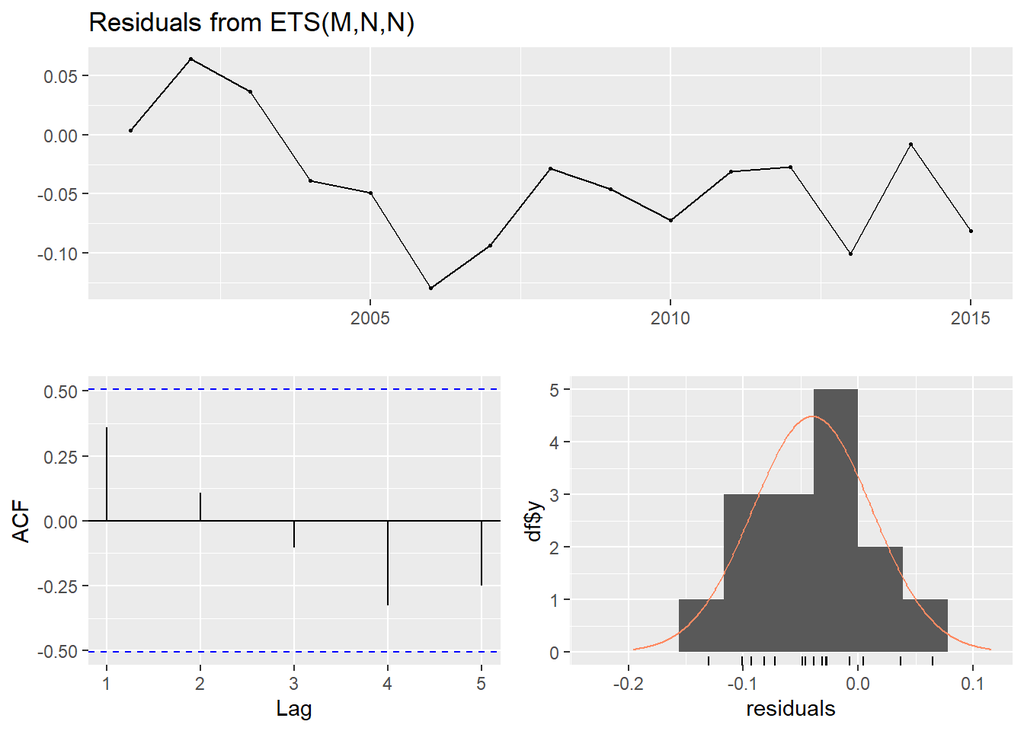

```
##
##  Ljung-Box test
##
## data:  Residuals from ETS(M,N,N)
## Q* = 6.8644, df = 3, p-value = 0.07635
##
## Model df: 2.   Total lags used: 5
```

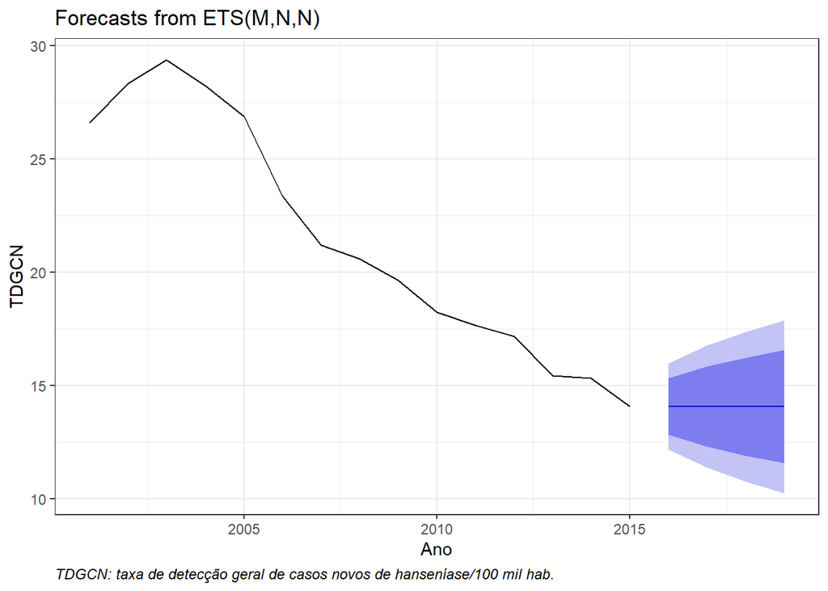

# ARIMA

```
##                       ME     RMSE       MAE        MPE      MAPE      MASE
## Training set 0.001833713 1.192373 0.8504051 -0.2784239  3.837538 0.6592288
## Test set     1.194285714 1.885575 1.6664286  8.7589992 12.619530 1.2918051
##                   ACF1 Theil's U
## Training set 0.3615801        NA
## Test set     0.2677282  3.063996
```

# ETS

```
##                      ME     RMSE      MAE       MPE     MAPE      MASE
## Training set -0.8288011 1.473630 1.211372 -4.452431 5.788826 0.9390484
## Test set     -1.0451250 1.173248 1.045125 -8.207841 8.207841 0.8101744
##                   ACF1 Theil's U
## Training set 0.4599207        NA
## Test set     0.1306843  1.280766
```

# Realizando predições até 2024

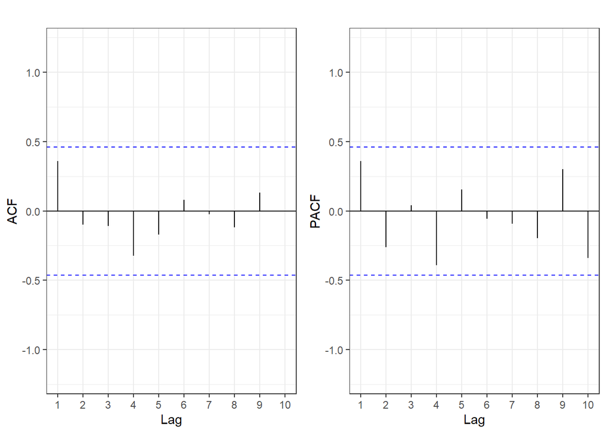

```
## [1] "FAC e FACP"
```

```
## Series: tx_geral
## ARIMA(0,1,0) with drift
##
## Coefficients:
##         drift
##       -0.7433
## s.e.   0.2903
##
## sigma^2 estimated as 1.606:  log likelihood=-29.29
## AIC=62.58   AICc=63.38   BIC=64.36
```

```
##      Point Forecast     Lo 80    Hi 80     Lo 95    Hi 95
## 2020      12.486667 10.862613 14.11072 10.002890 14.97044
## 2021      11.743333  9.446574 14.04009  8.230743 15.25592
## 2022      11.000000  8.187056 13.81294  6.697973 15.30203
## 2023      10.256667  7.008558 13.50477  5.289114 15.22422
## 2024       9.513333  5.881838 13.14483  3.959440 15.06723
```

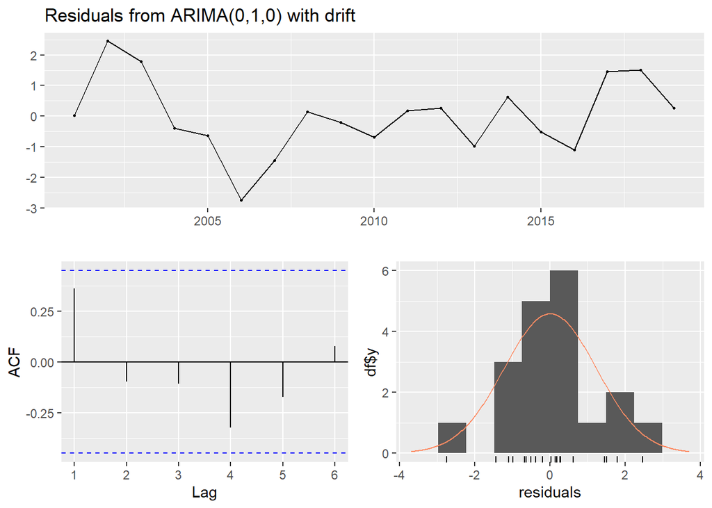

```
##
##  Ljung-Box test
##
## data:  Residuals from ARIMA(0,1,0) with drift
## Q* = 6.2184, df = 3, p-value = 0.1015
##
## Model df: 1.   Total lags used: 4
```

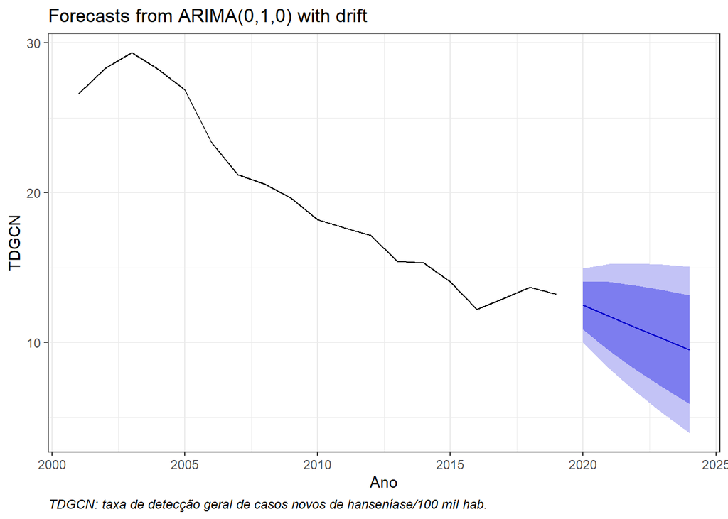

A estimativa é de uma taxa de 9,51 por 100 mil (IC95%: 3,96; 15,07) até 2024.

Deve se destacar que a análise aqui realizada não contempla os efeitos da pandemia da COVID-19, para tal seria necessária uma outra abordagem.